# Tratamiento de datos: Kickstarter Projects

Caso práctico orientado a aprender a identificar los datos relevantes para un proyecto analítico y usar las herramientas de integración, limpieza, validación y análisis de las mismas.

**Fuente de datos:** https://www.kaggle.com/kemical/kickstarter-projects

# Manejador de librerias

```r
if (!require("pacman")){
    install.packages("pacman")
}
```

```r
suppressWarnings(library(pacman))
pacman::p_load(dplyr, janitor, summarytools, lubridate, dlookr, nortest, DataExplorer, data.table, ggplot2)
```

# Carga de datos

```r
setwd("C:/Users/jreyrodr/OneDrive - Universitat Oberta de Catalunya/Master_UoC/Tipologia y ciclo de vida de los datos/ciclo_vida_datos/data/")
#setwd("C:/Users/Usuario/Downloads/ciclo_vida_datos-main/data")
fname = 'ks-projects-201801.csv'
ks_df = data.table::fread(fname, sep =',')
```

# Estandarización de nombres de las variables

```r
ks_df = janitor::clean_names(ks_df)
```

# Estructura del dataset

```r
print(summarytools::dfSummary(ks_df), method = 'render')
```

Data Frame Summary

ks_df

**Dimensions**: 378661 x 15  
**Duplicates**: 0

| **No** | **Variable** | **Stats / Values** | **Freqs (% of Valid)** | **Graph** | **Valid** | **Missing** |
| --- | --- | --- | --- | --- | --- | --- |
| 1 | id [integer] | Mean (sd) : 1074731192 (619086204.3) min < med < max: 5971 < 1075275634 < 2147476221 IQR (CV) : 1071885108 (0.6) | 378661 distinct values |  | 378661 (100%) | 0 (0%) |
| 2 | name [character] | 1. New EP/Music Development 2. Canceled (Canceled) 3. Music Video 4. N/A (Canceled) 5. Cancelled (Canceled) 6. Debut Album 7. New EP / Music Developmen 8. Reflections 9. The Journey 10. The Other Side… | 41 ( 0.0% ) 13 ( 0.0% ) 11 ( 0.0% ) 11 ( 0.0% ) 10 ( 0.0% ) 10 ( 0.0% ) 10 ( 0.0% ) 9 ( 0.0% ) 9 ( 0.0% ) 9 ( 0.0% ) 378528 ( 100.0% ) |  | 378661 (100%) | 0 (0%) |
| 3 | category [character] | 1. Product Design 2. Documentary 3. Music 4. Tabletop Games 5. Shorts 6. Video Games 7. Food 8. Film & Video 9. Fiction 10. Fashion [ 149 others ] | 22314 ( 5.9% ) 16139 ( 4.3% ) 15727 ( 4.2% ) 14180 ( 3.7% ) 12357 ( 3.3% ) 11830 ( 3.1% ) 11493 ( 3.0% ) 10108 ( 2.7% ) 9169 ( 2.4% ) 8554 ( 2.3% ) 246790 ( 65.2% ) |  | 378661 (100%) | 0 (0%) |
| 4 | main_category [character] | 1. Film & Video 2. Music 3. Publishing 4. Games 5. Technology 6. Design 7. Art 8. Food 9. Fashion 10. Theater [ 5 others ] | 63585 ( 16.8% ) 51918 ( 13.7% ) 39874 ( 10.5% ) 35231 ( 9.3% ) 32569 ( 8.6% ) 30070 ( 7.9% ) 28153 ( 7.4% ) 24602 ( 6.5% ) 22816 ( 6.0% ) 10913 ( 2.9% ) 38930 ( 10.3% ) |  | 378661 (100%) | 0 (0%) |
| 5 | currency [character] | 1. USD 2. GBP 3. EUR 4. CAD 5. AUD 6. SEK 7. MXN 8. NZD 9. DKK 10. CHF [ 4 others ] | 295365 ( 78.0% ) 34132 ( 9.0% ) 17405 ( 4.6% ) 14962 ( 4.0% ) 7950 ( 2.1% ) 1788 ( 0.5% ) 1752 ( 0.5% ) 1475 ( 0.4% ) 1129 ( 0.3% ) 768 ( 0.2% ) 1935 ( 0.5% ) |  | 378661 (100%) | 0 (0%) |
| 6 | deadline [character] | 1. 2014-08-08 2. 2014-08-10 3. 2014-08-07 4. 2015-05-01 5. 2014-08-09 6. 2015-07-01 7. 2015-04-01 8. 2014-08-15 9. 2014-08-31 10. 2014-08-14 [ 3154 others ] | 705 ( 0.2% ) 558 ( 0.1% ) 541 ( 0.1% ) 489 ( 0.1% ) 477 ( 0.1% ) 449 ( 0.1% ) 430 ( 0.1% ) 423 ( 0.1% ) 420 ( 0.1% ) 413 ( 0.1% ) 373756 ( 98.7% ) |  | 378661 (100%) | 0 (0%) |
| 7 | goal [numeric] | Mean (sd) : 49080.8 (1183391.3) min < med < max: 0 < 5200 < 1e+08 IQR (CV) : 14000 (24.1) | 8353 distinct values |  | 378661 (100%) | 0 (0%) |
| 8 | launched [character] | 1. 1970-01-01 01:00:00 2. 2009-09-15 05:56:28 3. 2010-06-30 17:29:43 4. 2011-02-08 04:29:48 5. 2011-02-25 09:58:36 6. 2011-03-03 17:55:38 7. 2011-03-07 17:11:18 8. 2011-04-12 20:08:32 9. 2011-06-07 06… | 7 ( 0.0% ) 2 ( 0.0% ) 2 ( 0.0% ) 2 ( 0.0% ) 2 ( 0.0% ) 2 ( 0.0% ) 2 ( 0.0% ) 2 ( 0.0% ) 2 ( 0.0% ) 2 ( 0.0% ) 378636 ( 100.0% ) |  | 378661 (100%) | 0 (0%) |
| 9 | pledged [numeric] | Mean (sd) : 9683 (95636) min < med < max: 0 < 620 < 20338986.3 IQR (CV) : 4046 (9.9) | 62130 distinct values |  | 378661 (100%) | 0 (0%) |
| 10 | state [character] | 1. canceled 2. failed 3. live 4. successful 5. suspended 6. undefined | 38779 ( 10.2% ) 197719 ( 52.2% ) 2799 ( 0.7% ) 133956 ( 35.4% ) 1846 ( 0.5% ) 3562 ( 0.9% ) |  | 378661 (100%) | 0 (0%) |
| 11 | backers [integer] | Mean (sd) : 105.6 (907.2) min < med < max: 0 < 12 < 219382 IQR (CV) : 54 (8.6) | 3963 distinct values |  | 378661 (100%) | 0 (0%) |
| 12 | country [character] | 1. US 2. GB 3. CA 4. AU 5. DE 6. N,0"" 7. FR 8. IT 9. NL 10. ES [ 13 others ] | 292627 ( 77.3% ) 33672 ( 8.9% ) 14756 ( 3.9% ) 7839 ( 2.1% ) 4171 ( 1.1% ) 3797 ( 1.0% ) 2939 ( 0.8% ) 2878 ( 0.8% ) 2868 ( 0.8% ) 2276 ( 0.6% ) 10838 ( 2.9% ) |  | 378661 (100%) | 0 (0%) |
| 13 | usd_pledged [numeric] | Mean (sd) : 7036.7 (78639.7) min < med < max: 0 < 394.7 < 20338986.3 IQR (CV) : 3017.1 (11.2) | 95455 distinct values |  | 374864 (99%) | 3797 (1%) |
| 14 | usd_pledged_real [numeric] | Mean (sd) : 9058.9 (90973.3) min < med < max: 0 < 624.3 < 20338986.3 IQR (CV) : 4019 (10) | 106065 distinct values |  | 378661 (100%) | 0 (0%) |
| 15 | usd_goal_real [numeric] | Mean (sd) : 45454.4 (1152950.1) min < med < max: 0 < 5500 < 166361390.7 IQR (CV) : 13500 (25.4) | 50339 distinct values |  | 378661 (100%) | 0 (0%) |

Generated by summarytools 0.9.6 ([R](https://www.r-project.org/) version 3.6.1)  
2021-06-07

# Limpieza de datos

## Conversión variables categóricas

```r
categorical_data = c("category", "main_category", "currency", "state", "country")
ks_df[,(categorical_data):= lapply(.SD, as.factor), .SDcols = categorical_data]
sapply(ks_df[, ..categorical_data], class)
```

```
##      category main_category      currency         state       country
##      "factor"      "factor"      "factor"      "factor"      "factor"
```

## Conversión varaible numéricas

```r
numerical_data = c("goal", "pledged", "backers", "usd_pledged", "usd_pledged_real", "usd_goal_real")
ks_df[,(numerical_data):= lapply(.SD, as.numeric), .SDcols = numerical_data]
sapply(ks_df[, ..numerical_data], class)
```

```
##             goal          pledged          backers      usd_pledged
##        "numeric"        "numeric"        "numeric"        "numeric"
## usd_pledged_real    usd_goal_real
##        "numeric"        "numeric"
```

## Conversión variables fecha

```r
ks_df$deadline = lubridate::ymd(ks_df$deadline)
ks_df$launched = lubridate::ymd_hms(ks_df$launched)
```

## Verificación no duplicados

No existen duplicados

```r
ks_df_d <- distinct(ks_df)
nrow(ks_df_d) == nrow(ks_df)
```

```
## [1] TRUE
```

## Seleccion de datos

```r
ks_df <- select(ks_df, -c(goal, pledged, currency, usd_pledged))
```

## Reduccion de casos: Filtro de proyectos

Interesa conocer los proyectos cancelados, en activo , exitosos…Luego, se eliminan los registros con estado “undefined”.

```r
ks_df = filter(ks_df, state != 'undefined')
ks_df = droplevels(ks_df)
```

## Conversion de variables: launched y deadline

Interesa saber el año de lanzamiento del proyecto y el periodo de recaudacion de fondos, más que las fechas concretas de lanzamiento y de finalizacion.

```r
ks_df$launch_year = as.integer(lubridate::year(ks_df$launched))
ks_df$days_of_campaign = as.integer(ks_df$deadline - as.Date(ks_df$launched))
ks_df = select(ks_df, -c(deadline, launched))
```

## Valores perdidos en los paises codificados con el nombre N,0"

```r
table(ks_df$country)
```

```
##
##     AT     AU     BE     CA     CH     DE     DK     ES     FR     GB     HK
##    597   7839    617  14756    761   4171   1113   2276   2939  33672    618
##     IE     IT     JP     LU     MX  N,0""     NL     NO     NZ     SE     SG
##    811   2878     40     62   1752    235   2868    708   1447   1757    555
##     US
## 292627
```

```r
levels(ks_df$country)[levels(ks_df$country)=='N,0"'] <- "UNKNOWN"
```

## Valores extremos

Resumen de valores extremos

```r
dlookr::diagnose_outlier(ks_df[, c("backers", "usd_goal_real", "usd_pledged_real", "days_of_campaign")])
```

| variables | outliers_cnt | outliers_ratio | outliers_mean | with_mean | without_mean |
| --- | --- | --- | --- | --- | --- |
| backers | 44713 | 11.92032 | 722.38823 | 106.62044 | 23.28511 |
| usd_goal_real | 44706 | 11.91845 | 327273.12616 | 45847.08077 | 7766.87693 |
| usd_pledged_real | 50576 | 13.48337 | 58255.16444 | 9123.93544 | 1466.97110 |
| days_of_campaign | 76282 | 20.33650 | 46.36962 | 34.49633 | 31.46531 |

Visualización de distribución de valores extremos con y sin.

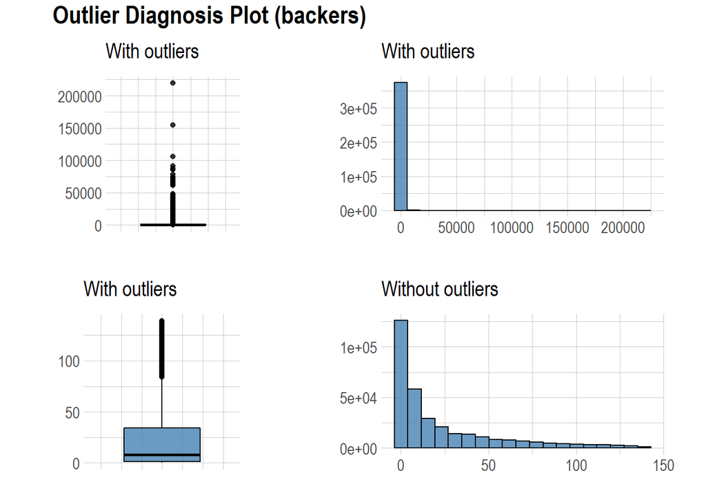

```r
ks_df %>% plot_outlier(backers)
```

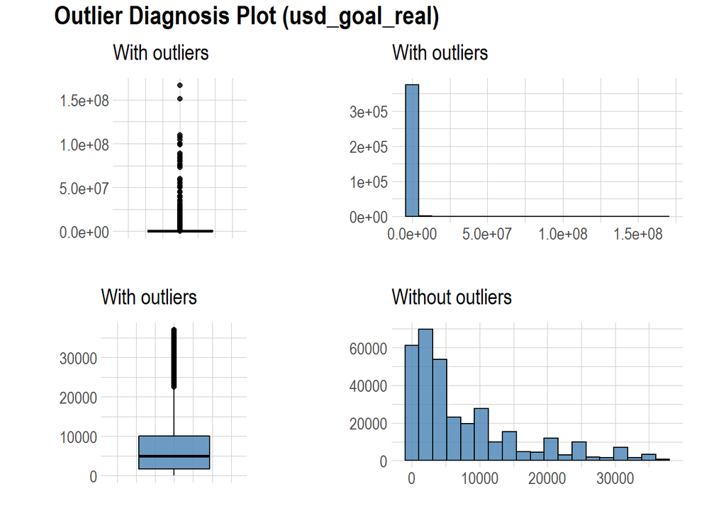

```r
ks_df %>% plot_outlier(usd_goal_real)
```

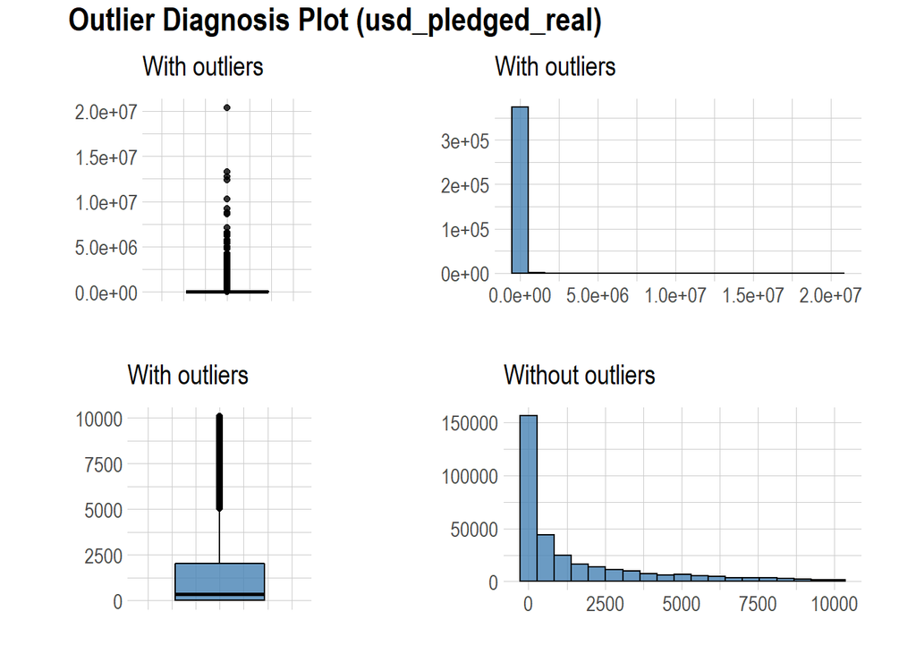

```r
ks_df %>% plot_outlier(usd_pledged_real)
```

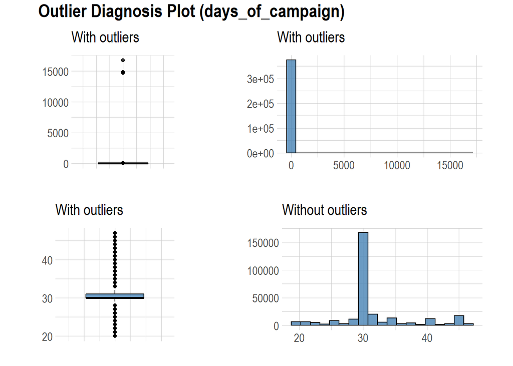

```r
ks_df %>% plot_outlier(days_of_campaign)
```

# Analisis de los datos

## Visualización variables discretas

```
## 2 columns ignored with more than 50 categories.
## name: 372291 categories
## category: 159 categories
```

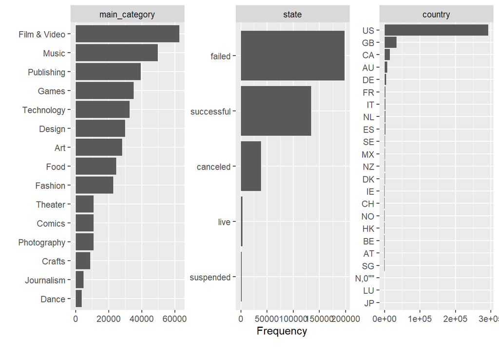

```r
plot_bar(ks_df)
```

## Distribución de densidad de variables continuas

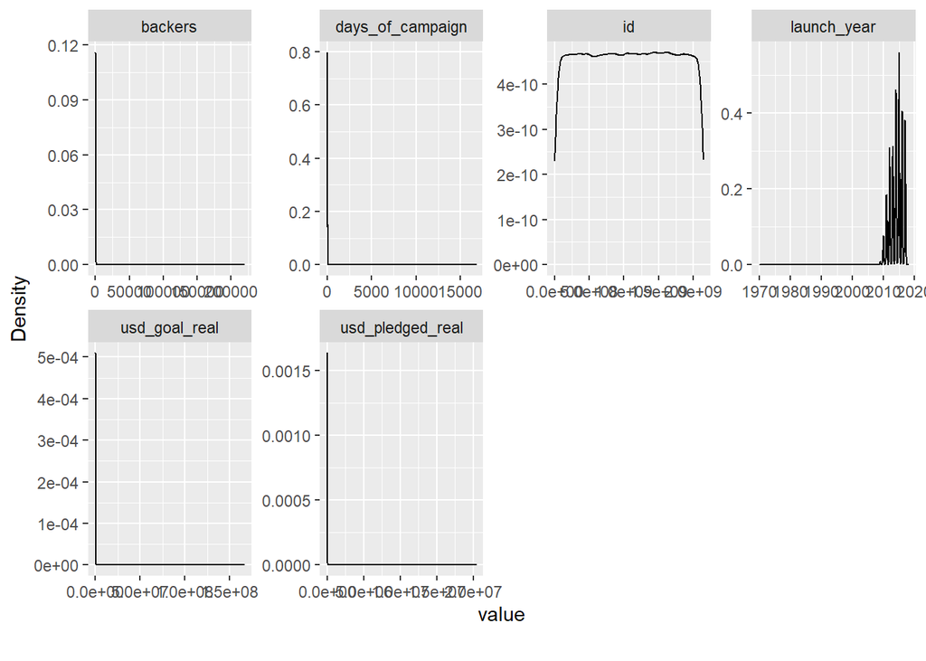

```r
plot_density(ks_df)
```

## Comprobación de la normalidad

```r
ks_df = as.data.frame(ks_df)
alpha = 0.05
col.names = colnames(ks_df)
for (i in 1:ncol(ks_df)) {
    if (i == 1) cat("Variables que no siguen una distribución normal:/n")
    if (is.integer(ks_df[,i]) | is.numeric(ks_df[,i])) {
        p_val = ad.test(ks_df[,i])$p.value
        if (p_val < alpha) {
            cat(col.names[i])
            # Format output
            if (i < ncol(ks_df) - 1) cat(", ")
            if (i %% 3 == 0) cat("/n")
        }
    }
}
```

```
## Variables que no siguen una distribución normal:/nid, backers, /nusd_pledged_real, usd_goal_real, /nlaunch_yeardays_of_campaign
```

## Quantile-quantile plots

Se pueden apreciar las variables que mas se acercan a una distribución normal

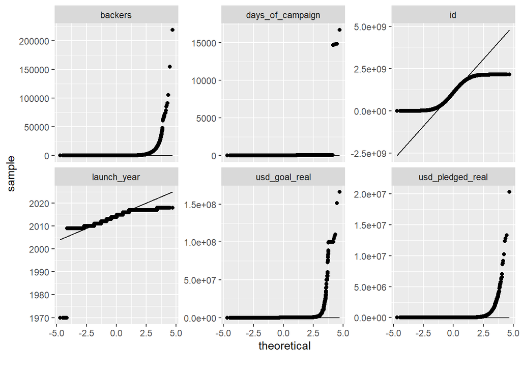

```r
plot_qq(ks_df)
```

## Comprobación Homogenidad de varianzas

En este caso, estudiaremos esta homogeneidad en cuanto a los grupos conformados por los tipos de categorias de crowdfunding. En el siguiente test, la hipótesis nula consiste en que ambas varianzas son iguales.

```r
fligner.test(usd_pledged_real ~ main_category, data = ks_df)
```

```
##
##  Fligner-Killeen test of homogeneity of variances
##
## data:  usd_pledged_real by main_category
## Fligner-Killeen:med chi-squared = 40053, df = 14, p-value < 2.2e-16
```

Dado que se obtiene un p-valor inferior a 0.05, rechazamos la hipótesis de que las varianzas de que las muestras por categorias son homogéneas.

## Correlación de variables númericas

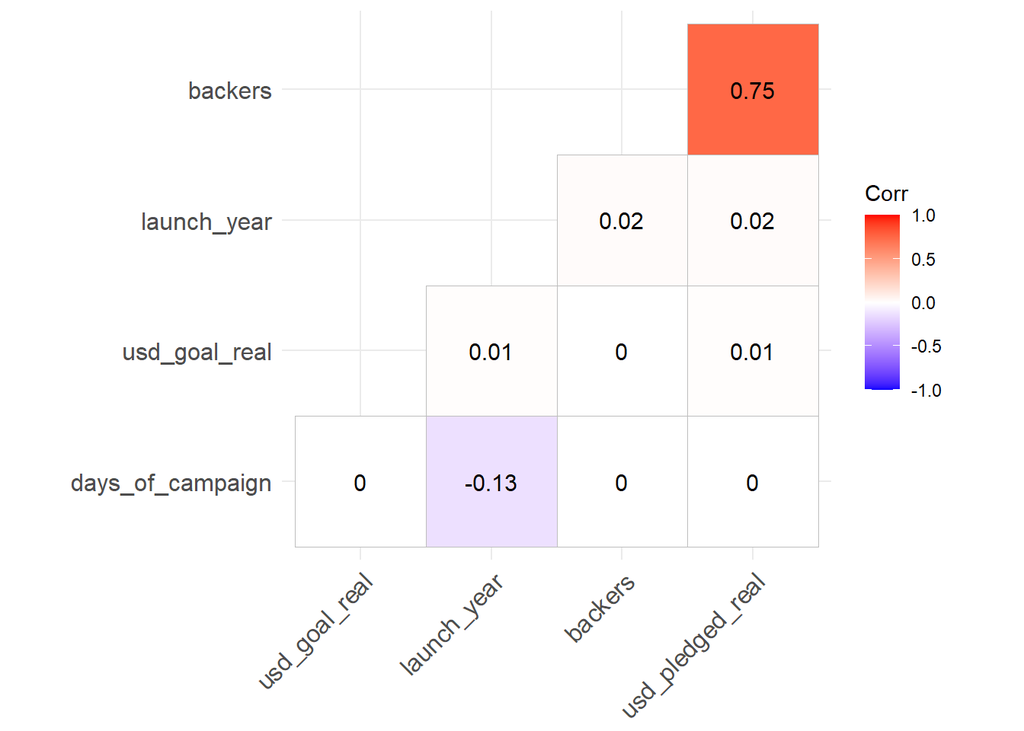

```r
r = cor(ks_df[, c("backers","usd_pledged_real", "usd_goal_real", "launch_year",
                  "days_of_campaign")],
        use="complete.obs")

ggcorrplot::ggcorrplot(r,
                       hc.order = TRUE,
                       type = "lower",
                       lab = TRUE)
```

## ¿Qué variables cuantitativas influyen más en la cantidad lograda en el crowdfunding?

```r
corr_matrix <- matrix(nc = 2, nr = 0)
colnames(corr_matrix) <- c("estimate", "p-value")
# Calcular el coeficiente de correlación para cada variable cuantitativa
# con respecto al campo "usd_pledged_real"
for (i in 1:(ncol(ks_df))) {
    if (is.integer(ks_df[,i]) | is.numeric(ks_df[,i])) {
        spearman_test = cor.test(ks_df[,i],
                                 ks_df[, "usd_pledged_real"],
                                 method = "spearman")
        corr_coef = spearman_test$estimate
        p_val = spearman_test$p.value
        # Add row to matrix
        pair = matrix(ncol = 2, nrow = 1)
        pair[1][1] = corr_coef
        pair[2][1] = p_val
        corr_matrix <- rbind(corr_matrix, pair)
        rownames(corr_matrix)[nrow(corr_matrix)] <- colnames(ks_df)[i]
    }
}
print(corr_matrix)
```

```
##                      estimate      p-value
## id               -0.001723277 2.912314e-01
## backers           0.958755792 0.000000e+00
## usd_pledged_real  1.000000000 0.000000e+00
## usd_goal_real     0.180384012 0.000000e+00
## launch_year      -0.067902966 0.000000e+00
## days_of_campaign  0.017190732 6.332847e-26
```

```r
goal_usd_us = ks_df[ks_df$country=="US", "usd_pledged_real"]
goal_usd_gb = ks_df[ks_df$country=="GB", "usd_pledged_real"]
t.test(goal_usd_us, goal_usd_gb = "less")
```

```
##
##  One Sample t-test
##
## data:  goal_usd_us
## t = 52.664, df = 292626, p-value < 2.2e-16
## alternative hypothesis: true mean is not equal to 0
## 95 percent confidence interval:
##   9310.302 10030.084
## sample estimates:
## mean of x
##  9670.193
```

```r
model_pledged <- lm(formula=usd_pledged_real~usd_goal_real+backers+
               launch_year, data=ks_df)
summary(model_pledged)
```

```
##
## Call:
## lm(formula = usd_pledged_real ~ usd_goal_real + backers + launch_year,
##     data = ks_df)
##
## Residuals:
##      Min       1Q   Median       3Q      Max
## -7771162    -2226    -1411     -213 14416873
##
## Coefficients:
##                 Estimate Std. Error t value Pr(>|t|)
## (Intercept)   -9.044e+05  1.020e+05  -8.865   <2e-16 ***
## usd_goal_real  1.644e-04  8.484e-05   1.937   0.0527 .
## backers        7.545e+01  1.078e-01 699.655   <2e-16 ***
## launch_year    4.496e+02  5.065e+01   8.875   <2e-16 ***
## ---
## Signif. codes:  0 '***' 0.001 '**' 0.01 '*' 0.05 '.' 0.1 ' ' 1
##
## Residual standard error: 60190 on 375095 degrees of freedom
## Multiple R-squared:  0.5664, Adjusted R-squared:  0.5664
## F-statistic: 1.633e+05 on 3 and 375095 DF,  p-value: < 2.2e-16
```

# Exportación datos limpios

```r
write.csv(ks_df, "KS_projects_clean.csv")
```